# Regression Linéaire

# TP

L’entreprise CITRON fabrique un matériau en matière plastique qui est utilisé dans la fabrication de jouets. Le département de contrôle qualité de l’entreprise a effectué une étude qui a pour but d’établir dans quelle mesure la résistance à la rupture (en kg/cm2) de cette matière plastique pouvait être affectée par l’épaisseur du matériau ainsi que la densité de ce matériau. Douze essais ont été effectués et les résultats sont présentés dans le tableau ci-dessous.

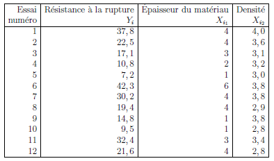

```r
Y<-c(37.8,22.5,17.1,10.8,7.2,42.3,30.2,19.4,14.8,9.5,32.4,21.6)
X1<-c(4,4,3,2,1,6,4,4,1,1,3,4)
X2<-c(4.0,3.6,3.1,3.2,3.0,3.8,3.8,2.9,3.8,2.8,3.4,2.8)
```

effectuer les analyses suivantes avec **R** et retrouver les résultats dans les tableaux.

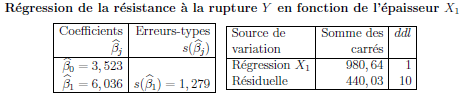

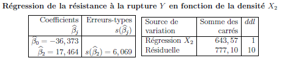

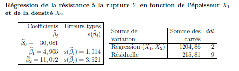

4. Quel pourcentage de variation dans la résistance à la rupture est expliqué Pour chacune de ces régressions ?
5. Entre l’épaisseur du matériau et la densité qu’est-ce qui a le plus d’influence sur la résistance à la rupture ?

# Corrigé (sans explication ! ce qui n’a aucun intérêt… A vous d’interpréter les résultats !!)

```r
model<-lm(formula = Y~X1)
summary(model)
```

```
##
## Call:
## lm(formula = Y ~ X1)
##
## Residuals:
##    Min     1Q Median     3Q    Max
## -8.266 -4.887 -1.208  3.232 10.770
##
## Coefficients:
##             Estimate Std. Error t value Pr(>|t|)
## (Intercept)    3.523      4.383   0.804 0.440237
## X1             6.036      1.279   4.721 0.000816 ***
## ---
## Signif. codes:  0 '***' 0.001 '**' 0.01 '*' 0.05 '.' 0.1 ' ' 1
##
## Residual standard error: 6.633 on 10 degrees of freedom
## Multiple R-squared:  0.6903, Adjusted R-squared:  0.6593
## F-statistic: 22.29 on 1 and 10 DF,  p-value: 0.0008155
```

```r
anova(model)
```

```
## Analysis of Variance Table
##
## Response: Y
##           Df Sum Sq Mean Sq F value    Pr(>F)
## X1         1 980.63  980.63  22.285 0.0008155 ***
## Residuals 10 440.03   44.00
## ---
## Signif. codes:  0 '***' 0.001 '**' 0.01 '*' 0.05 '.' 0.1 ' ' 1
```

```r
model<-lm(formula = Y~X2)
summary(model)
```

```
##
## Call:
## lm(formula = Y ~ X2)
##
## Residuals:
##      Min       1Q   Median       3Q      Max
## -15.1923  -5.1780  -0.2298   6.1123  12.3077
##
## Coefficients:
##             Estimate Std. Error t value Pr(>|t|)
## (Intercept)  -36.373     20.489  -1.775   0.1062
## X2            17.464      6.069   2.878   0.0164 *
## ---
## Signif. codes:  0 '***' 0.001 '**' 0.01 '*' 0.05 '.' 0.1 ' ' 1
##
## Residual standard error: 8.815 on 10 degrees of freedom
## Multiple R-squared:  0.453,  Adjusted R-squared:  0.3983
## F-statistic: 8.282 on 1 and 10 DF,  p-value: 0.01645
```

```r
anova(model)
```

```
## Analysis of Variance Table
##
## Response: Y
##           Df Sum Sq Mean Sq F value  Pr(>F)
## X2         1 643.57  643.57  8.2816 0.01645 *
## Residuals 10 777.10   77.71
## ---
## Signif. codes:  0 '***' 0.001 '**' 0.01 '*' 0.05 '.' 0.1 ' ' 1
```

```r
model<-lm(formula = Y~X1+X2)
summary(model)
```

```
##
## Call:
## lm(formula = Y ~ X1 + X2)
##
## Residuals:
##    Min     1Q Median     3Q    Max
## -6.897 -2.135 -1.126  1.714 10.122
##
## Coefficients:
##             Estimate Std. Error t value Pr(>|t|)
## (Intercept)  -30.081     11.455  -2.626 0.027542 *
## X1             4.905      1.014   4.838 0.000923 ***
## X2            11.072      3.621   3.058 0.013617 *
## ---
## Signif. codes:  0 '***' 0.001 '**' 0.01 '*' 0.05 '.' 0.1 ' ' 1
##
## Residual standard error: 4.897 on 9 degrees of freedom
## Multiple R-squared:  0.8481, Adjusted R-squared:  0.8143
## F-statistic: 25.12 on 2 and 9 DF,  p-value: 0.0002075
```

```r
anova(model)
```

```
## Analysis of Variance Table
##
## Response: Y
##           Df Sum Sq Mean Sq F value   Pr(>F)
## X1         1 980.63  980.63 40.8959 0.000126 ***
## X2         1 224.22  224.22  9.3509 0.013617 *
## Residuals  9 215.81   23.98
## ---
## Signif. codes:  0 '***' 0.001 '**' 0.01 '*' 0.05 '.' 0.1 ' ' 1
```